# Tempermental Torrance: Is California Cooling?

Allison Joseph

10/18/2017

Torrance is a coastal community in southwestern Los Angeles County, composed of about 1.5 miles of beaches on the Pacific Ocean and a heavily industrialized inland area (California Climate Change Center, 2010). Thus, coastal cooling can result from increasing ocean breezes that are induced by regional warming in inland areas. Unfortunately, coastal cooling trends can be distorted by climate change skeptics, who argue that a decrease or slowdown of warming is occurring. Some websites, blogs and articles in the media propose that it is not global warming we should be worried about, but instead global cooling. Yet, the data from Torrance does not support such claims, demonstrating an overall increase in temperature because of climate change. As temperatures continue to rise, Torrance and other coastal cities will be particularly vulnerable to natural hazards, including storms, extreme high tides, and rising sea levels (IPCC, 2014).

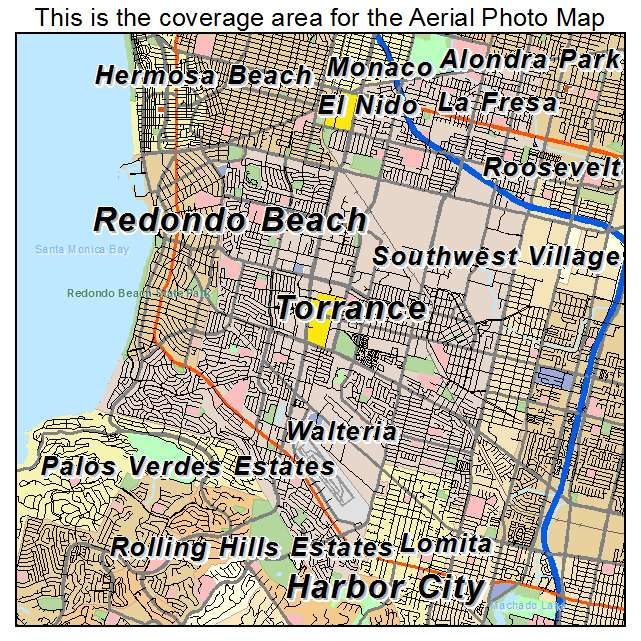

## Models

Using data from the National Oceanic and Atmospheric Association (NOAA) free online archive of historical weather and climate data from stations around the globe, climate data from January 1, 1932 to September 6, 2017 for station USW00003122 in Torrance, California was examined.

RStudio software was used to summarize, evaluate, and graphically present the data, creating a linear model and a trendline. Analysis of maximum and minimum temperatures (Fahrenheit) by month from 1932 to 2017 were used to account for daily and seasonal fluctuations in temperature.

Using the null hypothesis method, a standard scientific convention, the data was used to determine if there is a trend between time and temperature. The null hypothesis states that there is no relationship between temperature and time. The alternative hypothesis states that there is a relationship between temperature and time. Therefore, if the probability value (p-value) calculated is less than 0.05, the null hypothesis is rejected and a relationship can be assumed.

## Daily Data

The data shows a daily increase of .00005 degrees Fahrenheit, with a p-value of less than 0.001. Although such an increase does not seem to be that high, when multiplied by 365 (days) for 1 year, the average yearly increase was 0.02 degrees Fahrenheit. Over 100 years, the temperature increase for Torrance would be about 2 degrees Fahrenheit.

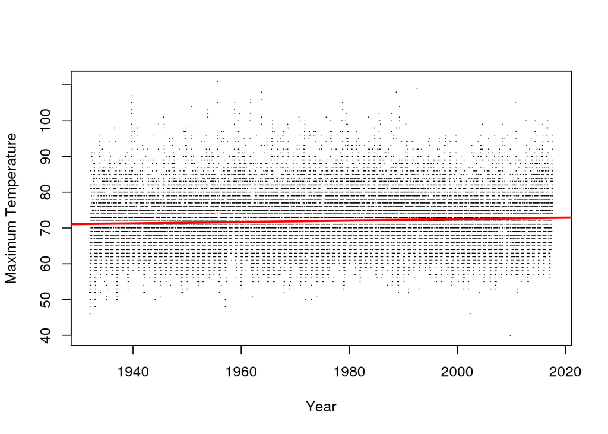

## Monthly Max Temperature Averages

January was chosen as an example month, because there is a trend for both maximum and minimum values. January shows a .04 monthly increase, with a p value of less than 0.05. Thus, January rejects the null hypothesis, showing a trend between time and temperature.

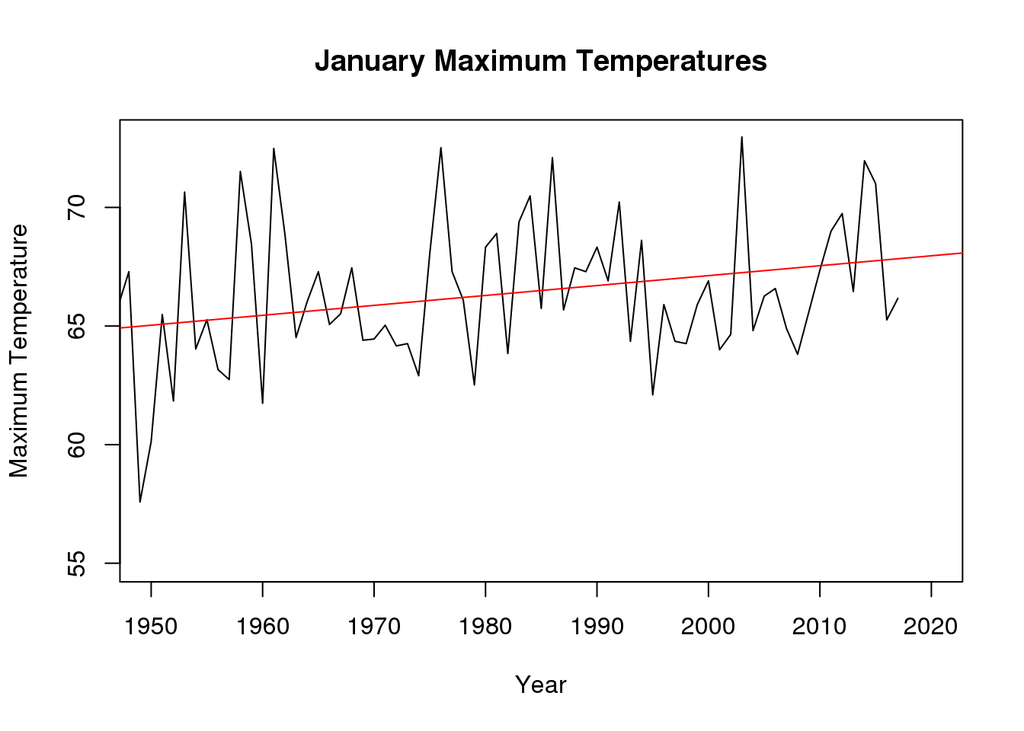

## Analyis of Maximum Temperature Data

January, March, April, June, and December (5/12 months) reject the null hypothesis.

The data shows that Torrance is generally warming, an increase in temperature exists for January, March, April, and June, supporting the idea that climate change is occurring.

In contrast, December shows a decrease in temperature. December’s cooling is surprising, for even California’s winter months show an increasing temperature trend.

## Minimum Monthly Temperatures

January shows a .08 monthly increase with a p value of less than 0.0001. The null hypothesis can be rejected, showing there is a trend between time and temperature.

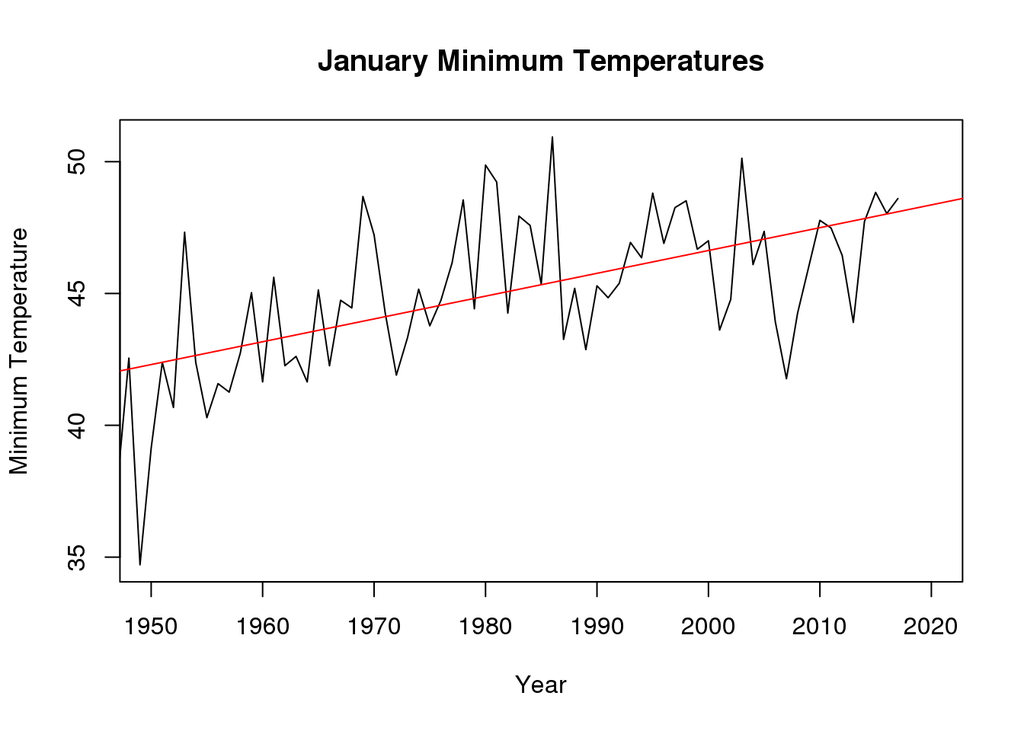

## Minimum Monthly Temperatures Data Analysis

For Torrance, all of the minimum daily temperatures are increasing, with a p < 0.05.

When comparing January’s temperature increase, the slope for January’s maximum temperature was .04, while January’s minimum temperature had a greater slope of .08. The rate of temperature increase for all monthly minimum temperatures was greater than their maximum temperature counterpart.

Thus, nights are warming at a faster rate than the daytime temperatures. Torrance reflects a pattern known as asymmetric warming, as minimum temperatures are increasing at a faster rate than maximum temperatures.

This lack of nighttime cooling has characterized recent heat waves in California, increasing the duration of such extreme events to 5 days or longer. Increased nightime temperatures place huge strains on California health, as heat-related mortality will become even more of a public health concern in the future.

## The Larger Context: Is Torrance’s Warming Significant?

Torrance’s rate of overall temperature increase is below the IPCC’s predicted rise of 3.6 degrees Fahrenheit in the next century. Thus, climate change skeptics may use this difference to argue that temperatures are decreasing and climate warming is slowing down. However, climate change warming is not uniform across the planet, varying from region to region. Temperature trends across the globe reflect the diverse geography on our planet, oceans versus continents, lowlands versus mountains, deserts versus ice sheets, as well as natural climate variability (Finkl, 2016). Often climate skeptics will zoom in on a certain set of data, “cherry picking” the trend that fits their claims. Yet, by zooming in on one region or time, one is not able to see the overall global trend of warming.

In addition, a two-degree change may sound like a small amount, yet it is an unusually large temperature change in a relatively short period of time. Climate skeptics may over-simplify the impact of such a rise, when in reality, Earth’s climate record shows that the global average temperature is stable over long periods of time. What may currently appear to be small changes in temperature will have relatively large impacts on Earth.

Thus, Torrance will face dangerous consequences from continued climate warming. As glaciers melt amid the heat of a warming planet, scientists predict that coastal communities in the United States will face severe challenges. In the past century, global mean sea level has increased by 7 to 8 inches and it is extremely likely (>95% probability) that human influence has been the dominant cause of observed atmospheric and oceanic warming (IPCC 2014). Global sea level is influenced by increasing temperatures, which result in the expansion of ocean waters as they warm and the addition of freshwater to the ocean from melting land-based ice sheets and glaciers (Earth Observatory, 2009).

Sea level rise is believed to be the most significant impact of climate change on California coastal areas (Environmental Protection Agency, 2014). Its main impacts include inundation/flooding, ecosystem change/wetland loss, coastal erosion, saltwater intrusion, and rising water levels. Tide gauges and satellite observations show that in the past century mean sea level in Los Angeles has risen 8 in (20 cm), keeping pace with the predicted global rise (NOAA, 2016).

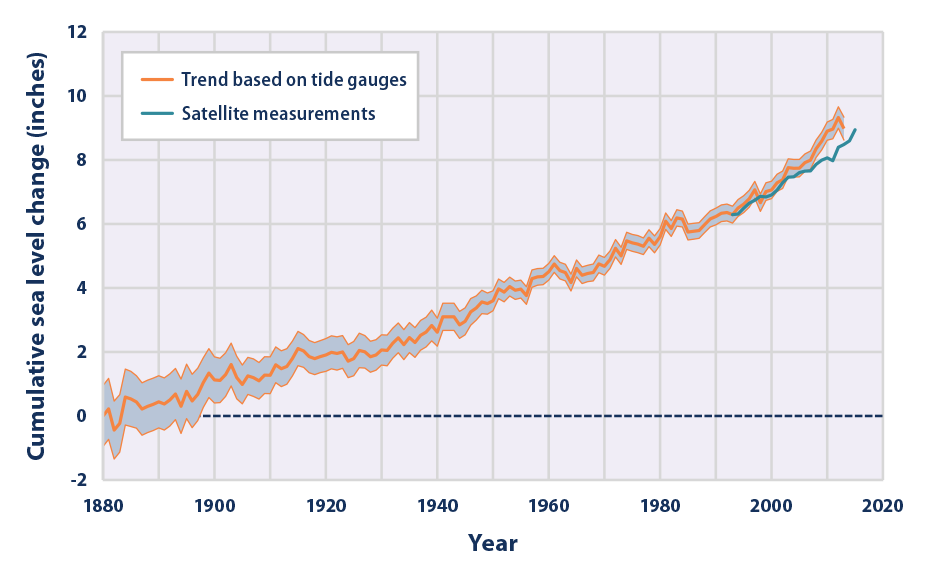

Iamge Source: NOAA, 2016

In response to the threat of rising sea levels, Torrance has partnered with the California Coastal Commission (CCC). Through its Sea Level Rise Policy Guidance, the CCC assists coastal cities in preparing for current and future sea level rise challenges (California Climate Change Center, 2010). Torrance’s neighboring cities are also in danger, “Some low-lying areas within the city’s jurisdiction, such as Venice Beach, and areas of Wilmington and San Pedro, are already vulnerable to flooding,” declared Phyllis Grifman, lead author of the report and associate director of the USC Sea Grant Program (2017). The vulnerability of such areas could place greater economic and infrastructural demands on the city of Torrance.

```
The impacts of sea level rise will affect almost every facet of our natural and manmade environments. Natural flooding, erosion, and storm event patterns are likely to be exacerbated by sea level rise, leading to significant economic, social, and environmental impacts for Los Angeles coastal cities.
```

## Economic Impacts

As sea levels continue to rise, Torrance will face economic challenges. Torrance is home to the U.S. headquarters of American Honda Motor Company, Robinson Helicopters and Southern California’s largest Exxon Mobil Refinery. As a major oil-producing region, Torrance was once dotted with thousands of oil wells and oil derricks. Though the oil wells are not as common as they once were, the ExxonMobil refinery in the north end of the city is responsible for much of Southern California’s gasoline supply. Thus, Torrance will face pressure to reduce greenhouse gas emissions as climate change impacts continue to increase. Torrance has created an Energy Efficiency Climate Action Plan (EECAP) to increase energy efficiency and lower GHG emissions. Along with the South Coast Air Quality Management Plan (AQMP), Torrance is working to design a policy that follows all federal and State air quality standards. Because of the importance of motor vehicles as a pollution source, the AQMP places substantial emphasis on reducing motor vehicle miles traveled. In addition, since 2013, the Torrance Exonn Mobil refinery has released more pollution into the air via unplanned flaring than the six other oil refineries in Southern California combined. In 2015, the AQMD belatedly discovered that ExxonMobil had released double the amount of sulfur dioxide the company initially reported, resulting in an 8.1 million fine. Since this incident, the city of Torrance has developed regulations to improve air quality standards and strategies to reduce vehicle emissions. Yet, such plans include the promotion of alternative fuels, which may threaten sectors of Torrance’s automotive industry.

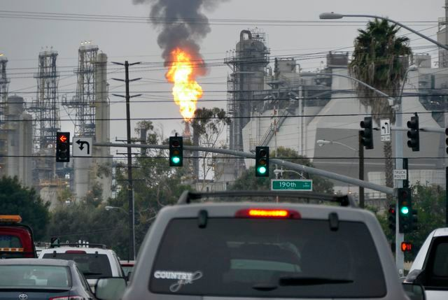

## Social Impacts

[output not shown]

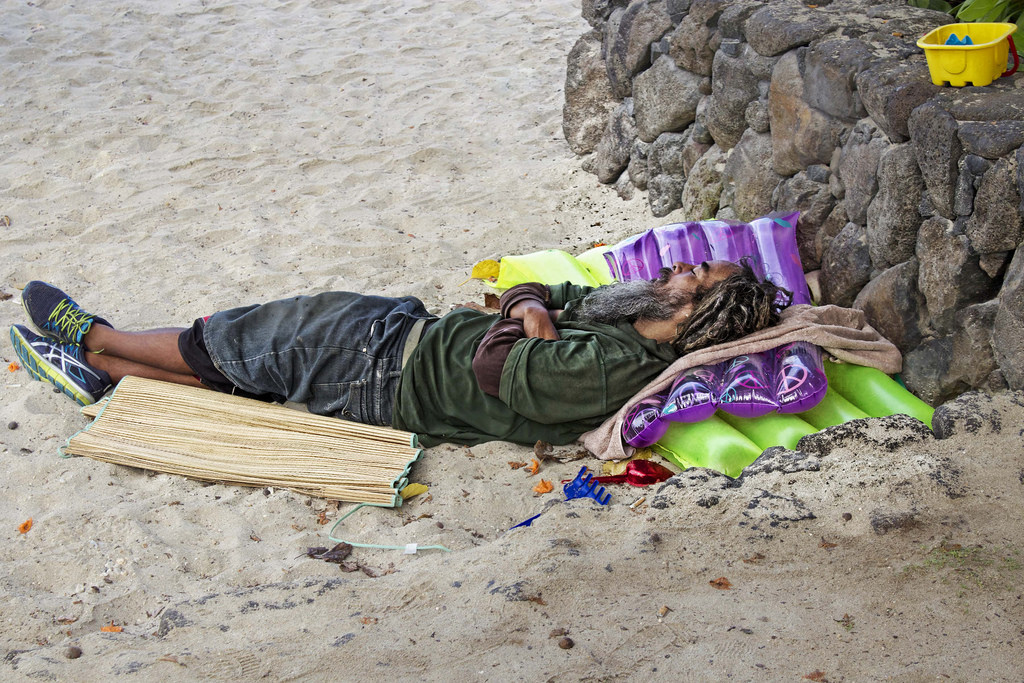

## Environmental Impacts

[output not shown]

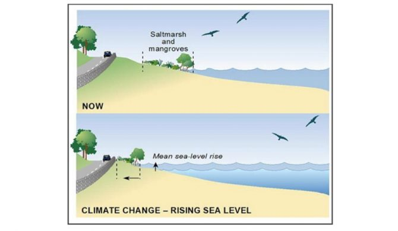

Source: Earth Observatory

## Conclusion

[output not shown]

## Resources

California Climate Change Center. (2010, March). THE IMPACTS OF SEA-LEVEL RISE ON THE CALIFORNIA COAST. Retrieved September 29, 2017, from https://www.coastal.ca.gov/climate/PI-cc-4-mm9.pdf

California Ocean Protection Council Science Advisory Team (OPC-SAT). (2017, February). Rising Seas in California AN UPDATE ON SEA-LEVEL RISE SCIENCE. Retrieved September 28, 2017, from http://www.opc.ca.gov/webmaster/ftp/pdf/docs/rising-seas-in-california-an-update-on-sea-level-rise-science.pdf

California State Lands Commission. (n.d.). Sea-Level Rise. Retrieved October 01, 2017, from http://www.slc.ca.gov/Programs/Sea_Level_Rise.html

City of Torrance. (2014). Torrance Transit Regional Park & Ride Air Quality & Climate Change Assessment. Retrieved September 27, 2017, from http://www.torranceca.gov/home/showdocument?id=2960

California Climate Action Registry , Y. (n.d.). Climate Change & California – Climate Registry. Retrieved October 01, 2017, from http://www.climateregistry.org/tools/member-resources/climate-change-basics/climate-hange-and-california.html

Earth Observatory. (2009, April). California Temperatures on the Rise : Image of the Day. Retrieved October 01, 2017, from https://www.earthobservatory.nasa.gov/IOTD/view.php?id=7596

Finnegan, M. (2014, May 13). Brown says rising sea levels could force costly move of LAX. Retrieved October 01, 2017, from http://www.latimes.com/local/political/la-mepc brown-sea-level-airports-20140513-story.html

Finkl, C. W. (2016). Retreat from a Rising Sea: Hard Choices in an Age of Climate Change. 2016. New York: Columbia University Press. Journal of Coastal Research, 322, 1510-1511.

Intergovernmental Panel on Climate Change. Working Group II: Impacts, Adaptation and Vulnerability. (2014). Retrieved September 28, 2017, from http://ipcc.ch/ipccreports/tar/wg2/index.php?idp=246

Intergovernmental Panel on Climate Change. Fifth Assessment Report. IPCC, 2014. Retrieved September 28, 2017, from https://www.ipcc.ch/report/ar5/wg3/

National Climatic Data Center, 2005: World Meteorological Organization, World Weather Records, 1991-2000, Volumes I-VI. U.S. Department of Commerce, NOAA, National Climatic Data Center, Asheville, NC, CDROM format

National Oceanic and Atmospheric Association. “Cooperative Observer Network (COOP).” National Climatic Data Center, USA Department of Commerce, November, 2016. www.ncdc.noaa.gov/data-access/land-based-station-data/land-based-datasets/cooperative-observer-network-coop. Accessed 28 Sept. 2017.

Netburn, D. (2017, February 9). L.A.’s mayor wants to lower the city’s temperature. These scientists are figuring out how to do it. Retrieved September 27, 2017, from http://www.latimes.com/projects/la-sci-cooling-los-angeles/

Parker, L. (2017, July 12). Sea Level Rise Will Flood Hundreds of Cities in the Near Future. Retrieved October 01, 2017, from http://news.nationalgeographic.com/2017/07/sea level-rise-flood-global-warming-science/

USC Sea Grant . (n.d.). Sea Level Rise Vulnerability Study for the City of Los Angeles > USC Sea Grant > USC Dana and David Dornsife College of Letters, Arts and Sciences. Retrieved October 01, 2017, from https://dornsife.usc.edu/uscseagrant/la-slr/